# 04_Biodiversity.Rmd

Morrow Zhang

2026-04-28

### Scientific Questions of Analysis

Scientific Question: Do hospitalized patients with major depressive disorder (MDD) who have made a recent suicide attempt exhibit higher gut microbial alpha diversity compared to MDD patients without a history of suicide attempts?

Alpha diversity Null hypothesis: There is no difference in gut microbial alpha diversity between hospitalized MDD patients with a recent suicide attempt and those without a history of suicide attempts.

Alternative hypothesis: Hospitalized MDD patients with a recent suicide attempt exhibit higher gut microbial alpha diversity across Hill diversity q = 0, q = 1, and q = 2 compared to MDD patients without a history of suicide attempts. Prior literature suggests that suicide-attempt status is associated with increased abundance of specific bacterial taxa, which may increase microbial richness (q = 0) and alter community evenness and dominance patterns reflected in q = 1 and q = 2.

# Set seed and Load Packages

```r
start_time <- Sys.time()
set.seed(238428)
pacman::p_load(tidyverse, devtools, patchwork, iNEXT, phyloseq,
               # packages for stats
               ggpubr, rstatix, install = FALSE)
```

# Load in data and make metadata dataframe

```r
# Load data
load("data/preprocessed_phyloseq.RData")
preprocessed_physeq
```

```
## phyloseq-class experiment-level object
## otu_table()   OTU Table:         [ 2886 taxa and 49 samples ]
## sample_data() Sample Data:       [ 49 samples by 37 sample variables ]
## tax_table()   Taxonomy Table:    [ 2886 taxa by 9 taxonomic ranks ]
```

```r
# Intuition check
min(sample_sums(preprocessed_physeq))
```

```
## [1] 12368
```

```r
# Create a metdata dataframe
metadata_df <-
  preprocessed_physeq %>%
  sample_data() %>%
  data.frame()

# Take a look at the metadata dataframe
glimpse(metadata_df)
```

```
## Rows: 49
## Columns: 37
## $ Run                            <chr> "SRR35320041", "SRR35320051", "SRR35320…
## $ Assay.Type                     <chr> "AMPLICON", "AMPLICON", "AMPLICON", "AM…
## $ AvgSpotLen                     <int> 600, 601, 601, 600, 600, 600, 600, 601,…
## $ Bases                          <int> 42870559, 52869386, 48220175, 41476966,…
## $ BioProject                     <chr> "PRJNA1321953", "PRJNA1321953", "PRJNA1…
## $ BioSample                      <chr> "SAMN51231085", "SAMN51231084", "SAMN51…
## $ BioSampleModel                 <chr> "MIMS.me,MIGS/MIMS/MIMARKS.human-gut", …
## $ Bytes                          <int> 27501260, 33837100, 30319981, 26186708,…
## $ Center.Name                    <chr> "JOHNS HOPKINS", "JOHNS HOPKINS", "JOHN…
## $ Collection_Date                <chr> "2020/2022", "2020/2022", "2020/2022", …
## $ collection_method              <chr> "rectal swab", "rectal swab", "rectal s…
## $ Consent                        <chr> "public", "public", "public", "public",…
## $ DATASTORE.filetype             <chr> "fastq,run.zq,sra", "fastq,run.zq,sra",…
```

[output cut: 24 more lines]

```r
# prepare iNEXT input data
# Species in rows while samples in columns
iNEXT_input_df <-
  preprocessed_physeq %>%
  otu_table() %>%
  data.frame()

# Take a look

dim(iNEXT_input_df)
```

```
## [1] 2886   49
```

```r
iNEXT_input_df[1:5, 1:5]
```

```
##          SRR35320041 SRR35320051 SRR35320062 SRR35320071 SRR35320072
## ASV_0001        2389        4973       12303        5214        4380
## ASV_0002        2874        2425        1127        2670        1699
## ASV_0003        5157        7284        1526        1070          71
## ASV_0004        3311        2111         153        1012         610
## ASV_0005         125         514         442        3010        1101
```

# Biodiversity Hill Numbers with iNEXT

```r
# Run iNEXT

#iNEXT_data <- iNEXT(
#  iNEXT_input_df,
#  q = c(0, 1, 2),
#  datatype = "abundance"
#)



#save(iNEXT_data, file = "data/iNEXT_data.RData")
```

```r
# Take a look

load("data/iNEXT_data.RData")
str(iNEXT_data)
```

```
## List of 3
##  $ DataInfo:'data.frame':    49 obs. of  14 variables:
##   ..$ Assemblage: chr [1:49] "SRR35320041" "SRR35320051" "SRR35320062" "SRR35320071" ...
##   ..$ n         : num [1:49] 38755 45635 45397 37841 27531 ...
##   ..$ S.obs     : num [1:49] 131 174 142 185 197 132 136 107 135 184 ...
##   ..$ SC        : num [1:49] 1 1 1 1 1 ...
##   ..$ f1        : num [1:49] 2 1 0 0 0 0 0 2 0 0 ...
##   ..$ f2        : num [1:49] 9 12 8 11 11 11 10 6 7 10 ...
##   ..$ f3        : num [1:49] 3 11 4 7 11 7 4 3 5 8 ...
##   ..$ f4        : num [1:49] 6 1 2 10 7 2 1 6 4 3 ...
##   ..$ f5        : num [1:49] 4 3 1 4 6 3 6 1 5 7 ...
##   ..$ f6        : num [1:49] 5 10 0 4 6 7 1 4 1 2 ...
##   ..$ f7        : num [1:49] 6 5 4 4 3 1 2 3 3 6 ...
##   ..$ f8        : num [1:49] 1 2 3 6 4 1 4 4 2 3 ...
##   ..$ f9        : num [1:49] 0 2 3 4 3 3 0 3 4 3 ...
##   ..$ f10       : num [1:49] 2 1 3 2 2 3 2 1 1 6 ...
##  $ iNextEst:List of 2
##   ..$ size_based    :'data.frame':   5880 obs. of  10 variables:
##   .. ..$ Assemblage: chr [1:5880] "SRR35320041" "SRR35320041" "SRR35320041" "SRR35320041" ...
##   .. ..$ m         : num [1:5880] 1 2153 4306 6459 8612 ...
##   .. ..$ Method    : chr [1:5880] "Rarefaction" "Rarefaction" "Rarefaction" "Rarefaction" ...
##   .. ..$ Order.q   : num [1:5880] 0 0 0 0 0 0 0 0 0 0 ...
##   .. ..$ qD        : num [1:5880] 1 88.9 103.8 111.4 116.3 ...
##   .. ..$ qD.LCL    : num [1:5880] 1 87.6 102 109.4 114.1 ...
##   .. ..$ qD.UCL    : num [1:5880] 1 90.2 105.5 113.5 118.5 ...
##   .. ..$ SC        : num [1:5880] 0.0692 0.9896 0.9954 0.9973 0.9982 ...
##   .. ..$ SC.LCL    : num [1:5880] 0.0684 0.9891 0.9951 0.997 0.998 ...
##   .. ..$ SC.UCL    : num [1:5880] 0.07 0.99 0.996 0.997 0.998 ...
##   ..$ coverage_based:'data.frame':   3576 obs. of  8 variables:
##   .. ..$ Assemblage: chr [1:3576] "SRR35320041" "SRR35320041" "SRR35320041" "SRR35320041" ...
##   .. ..$ SC        : num [1:3576] 0.0692 0.9896 0.9954 0.9973 0.9982 ...
##   .. ..$ m         : num [1:3576] 1 2153 4306 6459 8612 ...
##   .. ..$ Method    : chr [1:3576] "Rarefaction" "Rarefaction" "Rarefaction" "Rarefaction" ...
##   .. ..$ Order.q   : num [1:3576] 0 0 0 0 0 0 0 0 0 0 ...
##   .. ..$ qD        : num [1:3576] 1 88.9 103.8 111.4 116.3 ...
##   .. ..$ qD.LCL    : num [1:3576] 0.993 86.914 101.364 108.838 113.544 ...
##   .. ..$ qD.UCL    : num [1:3576] 1.01 90.92 106.16 114.02 119 ...
##  $ AsyEst  :'data.frame':    147 obs. of  7 variables:
##   ..$ Assemblage: chr [1:147] "SRR35320041" "SRR35320041" "SRR35320041" "SRR35320051" ...
##   ..$ Diversity : chr [1:147] "Species richness" "Shannon diversity" "Simpson diversity" "Species richness" ...
##   ..$ Observed  : num [1:147] 131 24.1 14.4 174 30.3 ...
##   ..$ Estimator : num [1:147] 131.2 24.1 14.5 174 30.4 ...
##   ..$ s.e.      : num [1:147] 5.639 0.188 0.105 4.1 0.247 ...
##   ..$ LCL       : num [1:147] 131 23.8 14.2 174 29.9 ...
##   ..$ UCL       : num [1:147] 142.3 24.5 14.7 182.1 30.8 ...
##  - attr(*, "class")= chr "iNEXT"
```

```r
typeof(iNEXT_data)
```

```
## [1] "list"
```

# Rarefaction Curves

```r
# Colors Preparation
color_df <-
  iNEXT_input_df %>%
  colnames() %>%
  data.frame()

head(color_df)
```

```
##             .
## 1 SRR35320041
## 2 SRR35320051
## 3 SRR35320062
## 4 SRR35320071
## 5 SRR35320072
## 6 SRR35320073
```

```r
colnames(color_df)[1] <- "names"

head(color_df)
```

```
##         names
## 1 SRR35320041
## 2 SRR35320051
## 3 SRR35320062
## 4 SRR35320071
## 5 SRR35320072
## 6 SRR35320073
```

```r
# Make a helper dataframe for plotting with colors

iNEXT_color_df <-
  color_df %>%
  # Merge with metadata
  left_join(metadata_df, by = c("names" = "Run")) %>%
  # Add colors for plotting by your real grouping
  mutate(
    AttemptStatus = ifelse(
      grepl("non attempters", source_material_id),
      "Non-attempter",
      "Attempter"
    ),
    attempt_colors = ifelse(
      AttemptStatus == "Non-attempter",
      "blue",
      "red"
    )
  )

head(iNEXT_color_df)
```

```
##         names Assay.Type AvgSpotLen    Bases   BioProject    BioSample
## 1 SRR35320041   AMPLICON        600 42870559 PRJNA1321953 SAMN51231085
## 2 SRR35320051   AMPLICON        601 52869386 PRJNA1321953 SAMN51231084
## 3 SRR35320062   AMPLICON        601 48220175 PRJNA1321953 SAMN51231083
## 4 SRR35320071   AMPLICON        600 41476966 PRJNA1321953 SAMN51231082
## 5 SRR35320072   AMPLICON        600 27932952 PRJNA1321953 SAMN51231126
## 6 SRR35320073   AMPLICON        600 27458118 PRJNA1321953 SAMN51231125
##                        BioSampleModel    Bytes   Center.Name Collection_Date
## 1 MIMS.me,MIGS/MIMS/MIMARKS.human-gut 27501260 JOHNS HOPKINS       2020/2022
## 2 MIMS.me,MIGS/MIMS/MIMARKS.human-gut 33837100 JOHNS HOPKINS       2020/2022
## 3 MIMS.me,MIGS/MIMS/MIMARKS.human-gut 30319981 JOHNS HOPKINS       2020/2022
## 4 MIMS.me,MIGS/MIMS/MIMARKS.human-gut 26186708 JOHNS HOPKINS       2020/2022
## 5 MIMS.me,MIGS/MIMS/MIMARKS.human-gut 17133688 JOHNS HOPKINS       2020/2022
## 6 MIMS.me,MIGS/MIMS/MIMARKS.human-gut 16680476 JOHNS HOPKINS       2020/2022
##   collection_method Consent DATASTORE.filetype DATASTORE.provider
```

[output cut: 55 more lines]

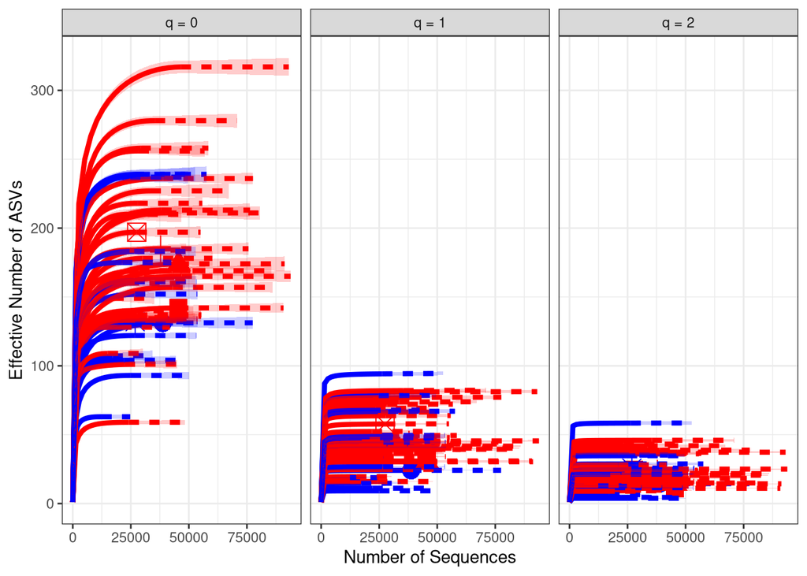

```r
inext_plot <- ggiNEXT(iNEXT_data, type = 1, facet.var = "Order.q") +
  scale_color_manual(values = iNEXT_color_df$attempt_colors) +
  scale_fill_manual(values = iNEXT_color_df$attempt_colors) +
  theme_bw() +
  theme(legend.position = "none") +
  labs(y = "Effective Number of ASVs", x = "Number of Sequences")
inext_plot
```

```r
# save my plot
ggsave(
  filename = "../figures/04_Biodiversity/iNEXT_curve.png",
  plot = inext_plot,
  width = 12,
  height = 6,
  dpi = 300
)
```